# Homework 8

Małgorzata Pujszo

Thursday, November 19, 2015

In the dataset Drosophila, we would like to explain pc1 by genotypes. I got the coefficients of the genotypes using 3 different methods:

1. calculating standard MLE estimators
2. using ridge regression
3. using LASSO regression

### a. MLE estimators

```r
library(PBImisc)
attach(Drosophila)
model <- lm(pc1~., data=bs[,1:42])
model$coefficients
```

```
##   (Intercept)           ewg             w            rp             v
##  3.234775e-02  3.511189e-04 -1.537647e-03 -1.574663e-04 -1.347338e-03
##            sd           run            gl           pgk            cg
##  5.127757e-04 -1.573789e-04 -1.014901e-03 -2.707906e-04 -1.553906e-03
##          gpdh         ninaC           glt           mhc           ddc
## -1.520561e-03 -1.365884e-03  2.980874e-04 -2.328605e-03  5.842563e-04
##           duc           sli          egfr           twi           zip
## -8.814409e-04 -7.975930e-04 -9.262804e-05 -2.267546e-05 -1.033398e-03
##           lsp            ve           acr           dbi             h
## -3.941309e-04 -1.364616e-03  2.710531e-04 -2.581086e-03 -4.358476e-04
##            fz           eip           tra           rdg            ht
## -4.371694e-03  1.256202e-03  1.314375e-05 -1.025004e-03 -2.019195e-03
##           ant         ninaE           fas           mst           odh
##  1.009427e-03 -1.895145e-03 -7.490480e-04 -1.013685e-03  4.492945e-04
##           tub            hb           rox           ald           mlc
## -1.708877e-03 -9.094134e-04 -1.562473e-03 -7.847963e-04 -8.373736e-04
##           jan           efi
## -1.681738e-03 -6.420986e-04
```

```r
max(abs(model$coefficients))
```

```
## [1] 0.03234775
```

```r
min(abs(model$coefficients))
```

```
## [1] 1.314375e-05
```

As we can see all the coefficients are pretty close to 0.

### b. Ridge regression estimators

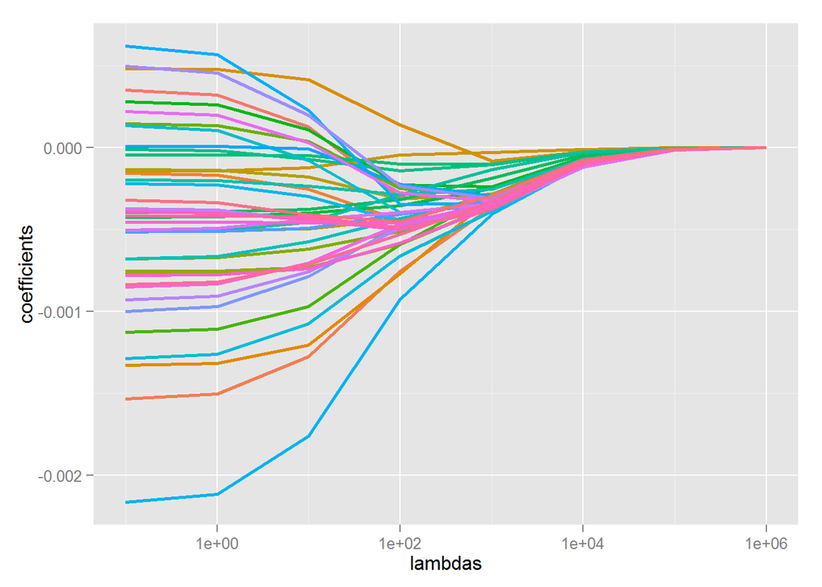

```r
lambdas <- 10^((-1):6)
coefs <- sapply(lambdas, function(lambda) {
  lm.ridge(pc1~., data=bs[,1:42], lambda=lambda)$coef
})
df2 <- data.frame(t(coefs), lambdas)
library(ggplot2)
library(reshape2)
mdf <- melt(df2, id="lambdas")
ggplot(mdf, aes(x=lambdas,y=value,color=variable)) +
  geom_line(size=1) + ylab("coefficients") + scale_x_log10() + theme(legend.position="none")
```

For all lambas coefficients are quite small (of order 10^(-3) or smaller). When lambda is bigger than 10^5, all coefficients are very close to 0, lambda equal to 0 obviously gives the same results as MLE estimators. If lambda is in (10^3, 10^5) many coefficients become closer to 0. For lambda in this interval we may choose smaller model which explains pc1 by not taking into acount variables which are almost 0. Here is an example when lambda=5*10^3. Minimal and maximal distance from 0 are calculated.

```r
model.ridge <- lm.ridge(pc1~., data=bs[,1:42], lambda=5*(10^3))
model.ridge$coef
```

```
##           ewg             w            rp             v            sd
## -1.127693e-04 -1.275070e-04 -1.003372e-04 -9.817402e-05 -4.716159e-05
##           run            gl           pgk            cg          gpdh
## -1.849653e-05 -1.253105e-04 -1.286343e-04 -1.508499e-04 -1.522623e-04
##         ninaC           glt           mhc           ddc           duc
## -1.499258e-04 -1.341675e-04 -1.181773e-04 -1.030735e-04 -1.045283e-04
##           sli          egfr           twi           zip           lsp
## -7.520456e-05 -4.432427e-05 -4.508110e-05 -5.426838e-05 -1.183178e-04
##            ve           acr           dbi             h            fz
## -1.418578e-04 -1.609652e-04 -1.717828e-04 -1.681234e-04 -1.785392e-04
##           eip           tra           rdg            ht           ant
## -1.669255e-04 -1.577792e-04 -1.747246e-04 -1.727454e-04 -1.702923e-04
##         ninaE           fas           mst           odh           tub
## -1.805803e-04 -1.907202e-04 -1.798355e-04 -1.764098e-04 -1.732878e-04
##            hb           rox           ald           mlc           jan
## -1.727866e-04 -1.667226e-04 -1.621089e-04 -1.663679e-04 -1.376378e-04
##           efi
## -1.250404e-04
```

```r
min(abs(model.ridge$coef))
```

```
## [1] 1.849653e-05
```

```r
max(abs(model.ridge$coef))
```

```
## [1] 0.0001907202
```

In comparison with previous model (MLE estimator) the furthest value from 0 is of order 10^(-4), not 10^(-2).

### c. LASSO regression estimators

Now I performed LASSO regression for a set of bounds.

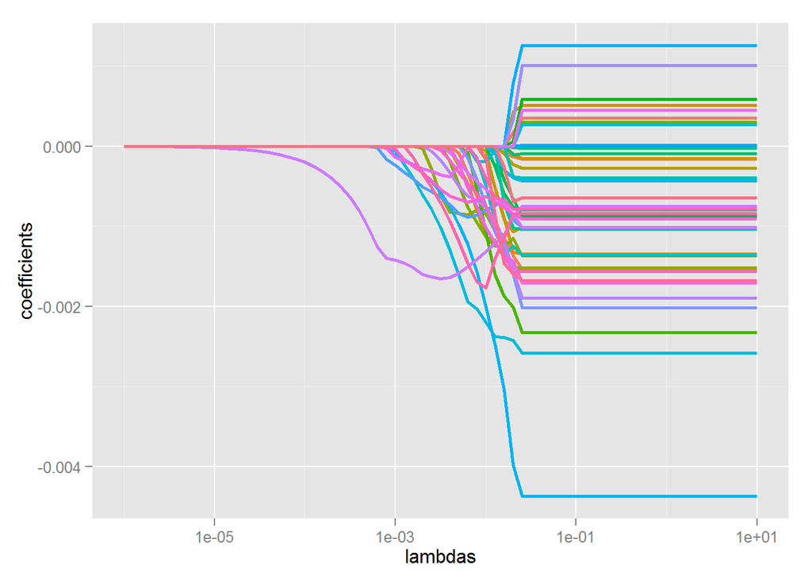

```r
library(lasso2)
lambdas <- 10^seq(-6,1,0.1)
coefs <- sapply(lambdas, function(lambda) {
  l1ce(pc1~., data=bs[,1:42], bound=lambda, absolute.t=TRUE)$coef
})
df2 <- data.frame(t(coefs), lambdas)[,-1]
mdf <- melt(df2, id="lambdas")
ggplot(mdf, aes(x=lambdas,y=value,color=variable)) +
  geom_line(size=1) + ylab("coefficients") + scale_x_log10() + theme(legend.position="none")
```

From the plot, we can observe that for lambda equal to about 5*10^(-2) and less, some coefficients become 0. When lambda reaches about 10^(-5), all coefficients are 0. Here is an example of bound=10^(-2).

```r
(coeffs <- l1ce(pc1~., data=bs[,1:42], bound=10^(-2), absolute.t=TRUE)$coef[-1])
```

```
##           ewg             w            rp             v            sd
##  0.0000000000 -0.0008541417  0.0000000000 -0.0001664100  0.0000000000
##           run            gl           pgk            cg          gpdh
##  0.0000000000 -0.0000639307  0.0000000000 -0.0011340329 -0.0008459149
##         ninaC           glt           mhc           ddc           duc
## -0.0011349194  0.0000000000 -0.0010833611  0.0000000000  0.0000000000
##           sli          egfr           twi           zip           lsp
##  0.0000000000  0.0000000000  0.0000000000  0.0000000000  0.0000000000
##            ve           acr           dbi             h            fz
## -0.0005012206 -0.0001946421 -0.0021991180  0.0000000000 -0.0020110964
##           eip           tra           rdg            ht           ant
##  0.0000000000  0.0000000000 -0.0007954042 -0.0007508758  0.0000000000
##         ninaE           fas           mst           odh           tub
## -0.0007644516 -0.0013171810 -0.0005414160  0.0000000000 -0.0010230339
##            hb           rox           ald           mlc           jan
## -0.0006277479 -0.0007530346 -0.0004047141 -0.0017702729 -0.0001472726
##           efi
##  0.0000000000
```

```r
length(coeffs[coeffs!=0])
```

```
## [1] 22
```

For such lambda we have 22 coefficients not equal to 0. So we can choose smaller model.

### Conclusions

In all three approaches the absolute values of coefficients are pretty small. When we consider ridge regression as a function of penalty, coefficients’ values are becoming closer to 0 (but not 0) with increasing lambdas. In the case of LASSO regression considering decreasing bounds, more and more coefficients become entirely 0.